# ANALYSIS OF DATA FROM BLUEPRINT FOREX APP

## What month had the highest opened trades?

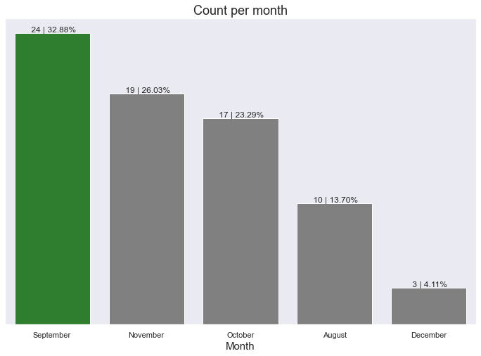

September recorded the highest number of opened trades

## What month had the highest closed trades?

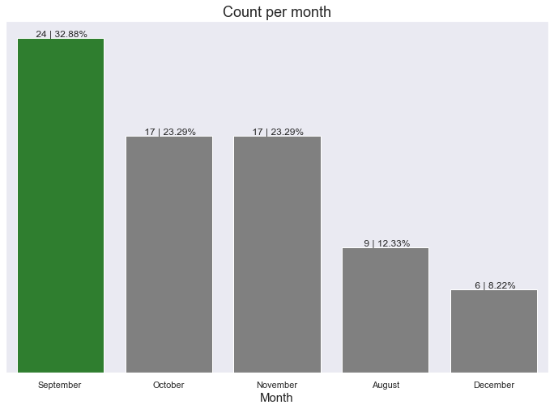

As expected, most opened trades had an average trade length of 0-5 days. This is why september also recorded the highest number of closed trades as well.

## What weekday had the highest trades?

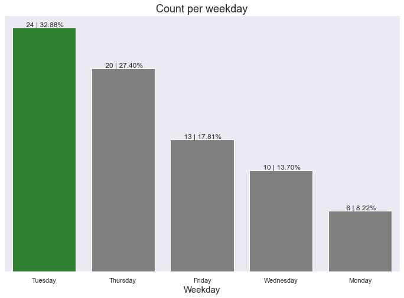

About 32% of all trades were opened on tuesday. This was the highest, compared to other weekdays. This is due to the fact that mondays were usually used to study the trends of the market for the week.

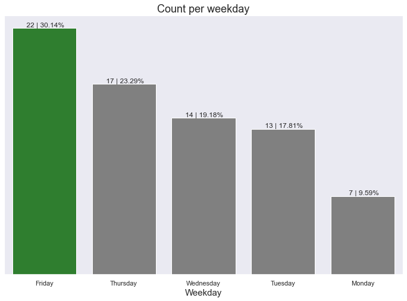

Most trades were closed on fridays, which marks the end of the trading week. There is no currency pair trading during the weekend. Trading usually resumes on sunday evening.

## Is there any relationship between the number of pips won and the number of trades entered?

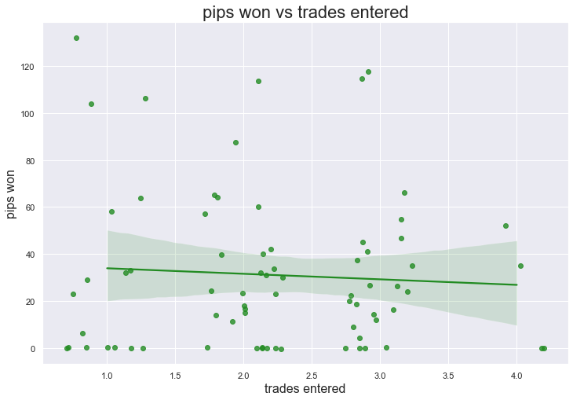

No significant relationship was observed between the number of pips won and the number of trades entered

## Is there any relationship between the trade length and the number of pips won?

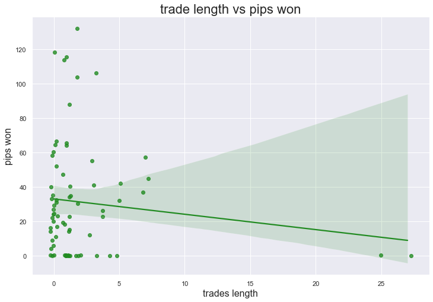

## What currency pair gave the highest number of pips won?

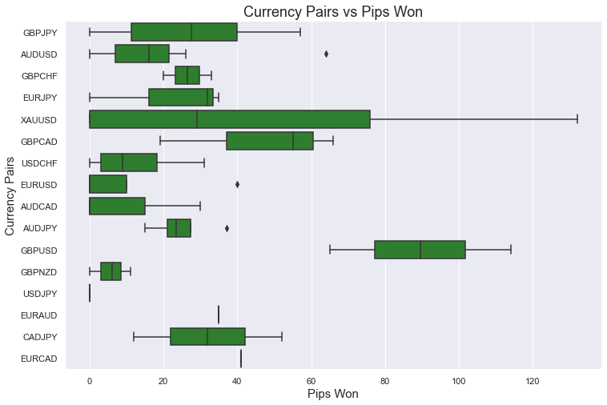

XAUUSD won the highest number of pips overall, however, the top 75% of all GBPUSD trades gave higher pips than the lower 75% of all XAUUSD trades. The median GBPUSD trade is higher than the median XAUUSD trade, but the top 25% of XAUUSD trades puts it in the lead. USDJPY recorded the least number of pips won overall.

## What month recorded the highest number of pips won?

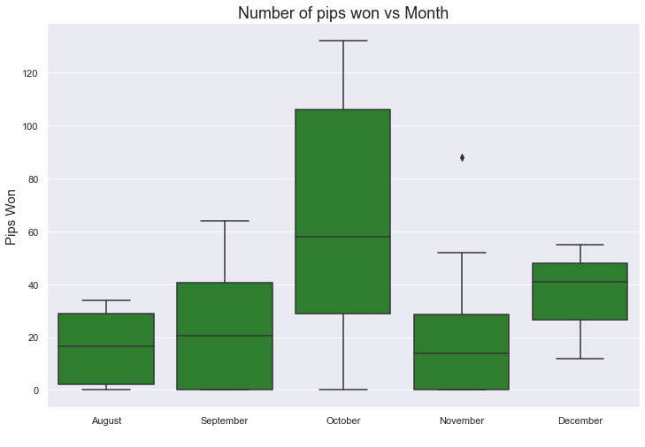

October recorded the highest number of pips won. **2271.2** pips were won throughout the 80 day trade period

## What month recorded the highest number of pips lost?

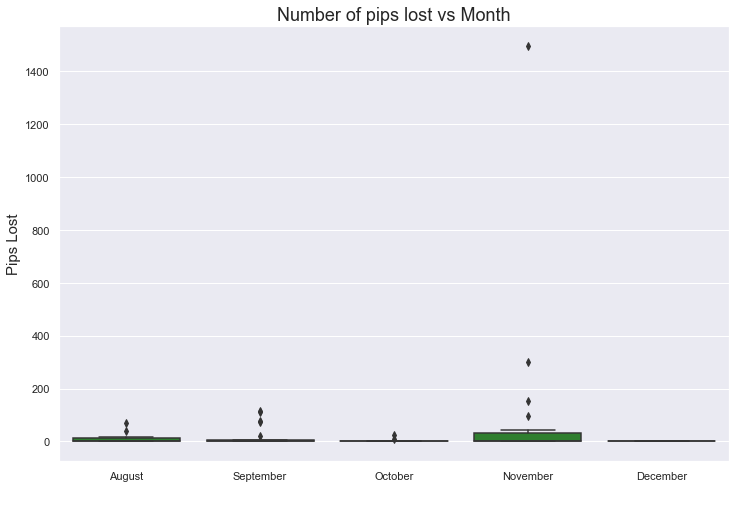

November recorded the highest number of pips lost. **2702** pips were lost throughout the 80 day trade period.

## What trade call (Buy or Sell) gave better pip returns?

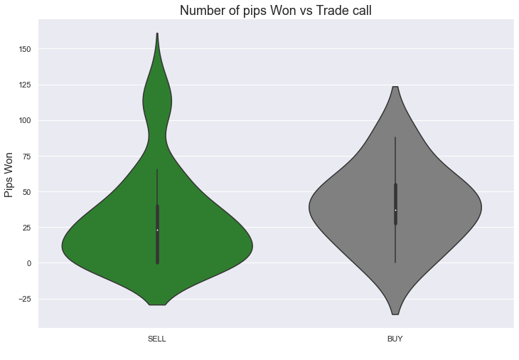

The sell call is multimodal, meaning the data distribution has more than one data cluster, compared to the buy call which is unimodal. The sell call has values with higher pips won compared to the buy call but this may be due to the fact that sell calls were significantly more than buy calls. However, i noticed that the median buy call was higher than the median sell call. This means that relatively, half of pips won from the buy call had higher values than half of pips won from the sell call.

## What results were observed within the buy and sell trade calls?

```
result  successful  unsuccessful
Trade
BUY              7             1
SELL            46            19
```

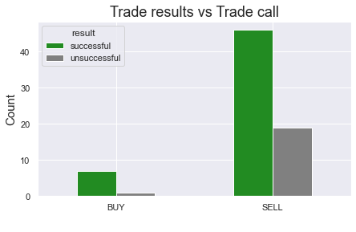

For both buy and sell trade calls, a higher number of successful trades were observed, compared to the unsuccessful ones.